# PCA Assignment

John Chandler

# PCA

This workbook walks through the PCA example from the lecture. We’ll read in the departmental data set and perform PCA on it. At the end of the workbook is a place for you to build your own PCA on sales on the top 1000 products by owner.

```r
# Input file should be in the same dir as RMD file
input_file <- "spend_by_dept_full.txt"

dept <- read_tsv(input_file)
dept <- dept %>%
  filter(total_spend>0) # drop people with negative or zero total spends.

# `dept` includes total spend, so we can
# get total spend by department.

dept.spend <- dept %>%
  melt(id.vars="owner",
       variable.name="department",
       value.name="spend.frac")

dept.spend <- merge(dept.spend,
                    dept %>% select(owner,total_spend),
                    all.x=T)

dept.spend <- dept.spend %>%
  filter(department != "total_spend") %>%
  mutate(amount = total_spend * spend.frac)

dept.spend <- dept.spend %>%
  group_by(department) %>%
  summarize(spend = sum(amount)) %>%
  ungroup %>%
  mutate(department = reorder(department,spend))
```

Now we’ve got the data read in. We have two data frames, one with the raw data and one with the department spend summary.

```r
Hmisc::describe(dept)
```

```
## dept
##
##  20  Variables      16699  Observations
## --------------------------------------------------------------------------------
## owner
##        n  missing distinct     Info     Mean      Gmd      .05      .10
##    16699        0    16699        1    21982    10964    10945    11855
##      .25      .50      .75      .90      .95
##    14616    19201    23802    48295    49139
##
## lowest : 10000 10001 10002 10003 10004, highest: 49997 49998 49999 50000 50001
## --------------------------------------------------------------------------------
## BAKEHOUSE
##        n  missing distinct     Info     Mean      Gmd      .05      .10
##    16699        0       47    0.534 0.006021  0.01072     0.00     0.00
##      .25      .50      .75      .90      .95
##     0.00     0.00     0.00     0.01     0.03
##
## lowest : 0.00 0.01 0.02 0.03 0.04, highest: 0.66 0.68 0.87 0.92 1.00
## --------------------------------------------------------------------------------
## BEER & WINE
##         n   missing  distinct      Info      Mean       Gmd       .05       .10
##     16699         0        29      0.05 0.0009707  0.001932         0         0
##       .25       .50       .75       .90       .95
##         0         0         0         0         0
##
## lowest : 0.00 0.01 0.02 0.03 0.04, highest: 0.50 0.54 0.58 0.63 1.00
## --------------------------------------------------------------------------------
## BREAD
##        n  missing distinct     Info     Mean      Gmd      .05      .10
##    16699        0       48     0.73  0.01018  0.01653     0.00     0.00
##      .25      .50      .75      .90      .95
##     0.00     0.00     0.01     0.03     0.05
##
## lowest : -0.01  0.00  0.01  0.02  0.03, highest:  0.60  0.62  0.75  0.83  1.00
## --------------------------------------------------------------------------------
## BULK
##        n  missing distinct     Info     Mean      Gmd      .05      .10
##    16699        0       99     0.98  0.07946  0.09981     0.00     0.00
##      .25      .50      .75      .90      .95
```

[output cut: 120 more lines]

```
##   147.18   569.66  1754.46  3930.06  5874.43
##
## lowest :      0.32      0.69      1.00      1.18      1.29
## highest: 273776.42 368544.30 374787.64 381576.69 855709.62
##
## Value           0  10000  20000  30000  40000  50000  70000  90000 100000
## Frequency   15568   1068     43      5      2      1      1      2      1
## Proportion  0.932  0.064  0.003  0.000  0.000  0.000  0.000  0.000  0.000
##
## Value      150000 210000 270000 370000 380000 860000
## Frequency       2      1      1      2      1      1
## Proportion  0.000  0.000  0.000  0.000  0.000  0.000
##
## For the frequency table, variable is rounded to the nearest 10000
## --------------------------------------------------------------------------------
```

```r
knitr::kable(dept.spend)
```

| department | spend |
| --- | --- |
| BAKEHOUSE | 99052.934 |
| BEER & WINE | 5330.106 |
| BREAD | 263480.012 |
| BULK | 2228464.057 |
| CHEESE | 786079.677 |
| DELI | 2165477.129 |
| FISH&SEAFOOD | 407837.285 |
| FLOWERS | 133466.171 |
| FROZEN | 1091488.883 |
| GEN MERCH | 540055.242 |
| HERBS&SPICES | 380586.267 |
| JUICE BAR | 370531.927 |
| MEAT | 2259102.219 |
| PACKAGED GROCERY | 5303266.594 |
| PERSONAL CARE | 1060903.909 |
| PRODUCE | 5705101.077 |
| REF GROCERY | 2881668.443 |
| SUPPLEMENTS | 1446984.838 |

Let’s also take a look at spends by department.

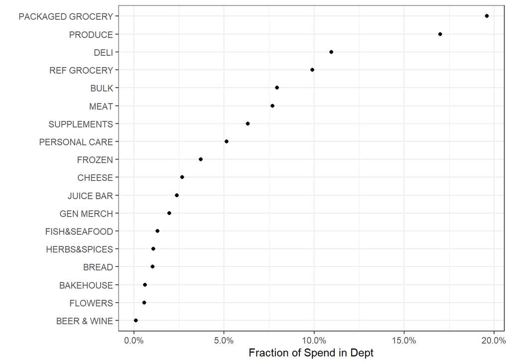

```r
for.plot <- melt(dept,
                 id.vars = "owner",
                 variable.name="dept",
                 value.name="spend.frac")

for.plot %>%
  filter(dept != "total_spend") %>%
  group_by(dept) %>%
  summarize(mean_pct = mean(spend.frac)) %>%
  mutate(dept = reorder(dept,mean_pct)) %>%
  ggplot(aes(x=mean_pct,y=dept)) +
  geom_point() +
  theme_bw() +
  labs(x="Fraction of Spend in Dept",
       y="") +
  scale_x_continuous(labels=percent)
```

## Visualizing correlations

Although it’s not strictly necessary, the lecture includes a heatmap of correlations. This is often a nice thing to include in papers, particularly when your audience wants you to do a “correlation analysis.” Here’s some code that does this:

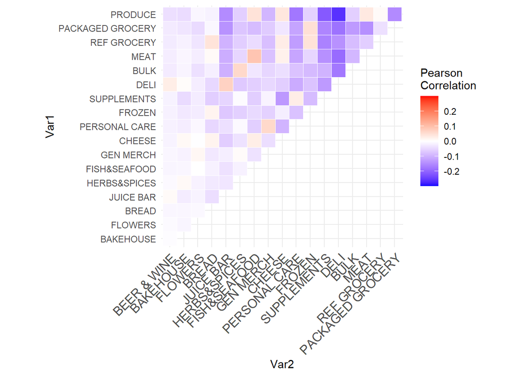

```r
dc <- cor(dept %>% select(-owner,-total_spend))
dc <- dc[,order(dept.spend$spend)]
dc <- dc[order(dept.spend$spend),]
dc[upper.tri(dc)] <- NA
diag(dc) <- NA

melted_cormat <- melt(dc)
melted_cormat <- na.omit(melted_cormat)

# Heatmap
# ggfortify also has some heatmap functionality, iirc
ggplot(data = melted_cormat, aes(Var2, Var1, fill = value))+
 geom_tile(color = "white")+
 scale_fill_gradient2(low = "blue", high = "red", mid = "white",
   midpoint = 0, limit = c(-0.3,0.3), name="Pearson\nCorrelation") +
  theme_minimal()+
 theme(axis.text.x = element_text(angle = 45, vjust = 1,
    size = 12, hjust = 1))+
 coord_fixed()
```

## Principal Components Analysis

Now we’ll walk through the fitting of the PCA.

```r
pca1 <- dept %>%
  select(-owner,-total_spend) %>%
  prcomp

summary(pca1)
```

```
## Importance of components:
##                           PC1    PC2    PC3    PC4     PC5     PC6     PC7
## Standard deviation     0.1720 0.1516 0.1500 0.1227 0.11516 0.10736 0.09852
## Proportion of Variance 0.1976 0.1535 0.1503 0.1005 0.08857 0.07697 0.06482
## Cumulative Proportion  0.1976 0.3511 0.5014 0.6019 0.69042 0.76740 0.83221
##                            PC8     PC9    PC10    PC11    PC12    PC13    PC14
## Standard deviation     0.08989 0.06462 0.06062 0.04945 0.04642 0.03821 0.03143
## Proportion of Variance 0.05396 0.02789 0.02454 0.01633 0.01439 0.00975 0.00660
## Cumulative Proportion  0.88617 0.91406 0.93860 0.95493 0.96932 0.97907 0.98566
##                           PC15    PC16    PC17     PC18
## Standard deviation     0.02962 0.02892 0.02070 0.002188
## Proportion of Variance 0.00586 0.00558 0.00286 0.000030
## Cumulative Proportion  0.99152 0.99711 0.99997 1.000000
```

Let’s make the plot that shows the standard deviations and cumulative variance from the summary.

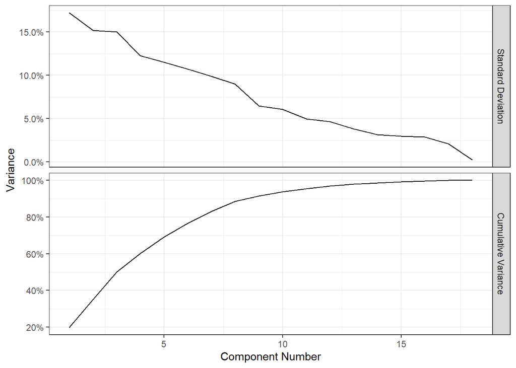

```r
for.plot <- data.frame(sd=pca1$sdev)
for.plot <- for.plot %>%
  mutate(eigs=sd^2) %>%
  mutate(cume.var = cumsum(eigs/sum(eigs)),
         id=1:n())

names(for.plot) <- c("Standard Deviation","eigs",
                     "Cumulative Variance","id")

for.plot <- melt(for.plot,
                 id.vars = "id")

ggplot(for.plot %>% filter(variable != "eigs"),
       aes(x=id,y=value)) +
  geom_line() +
  facet_grid(variable ~ .,
             scales="free") +
  theme_bw() +
  scale_y_continuous(label=percent) +
  labs(y="Variance",
       x="Component Number")
```

The biplots used an old package but now use `ggfortify`, which makes life much easier.

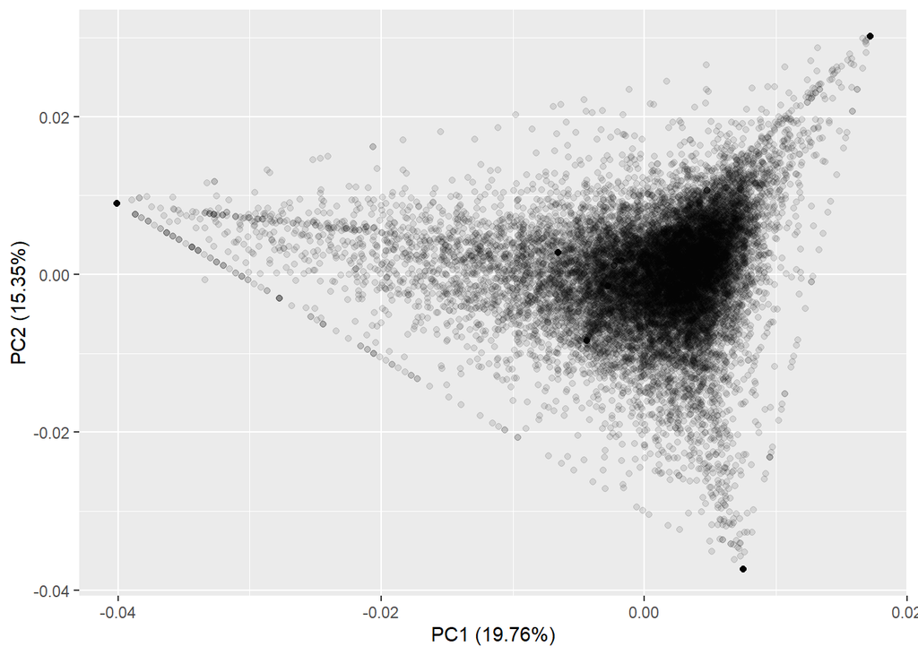

```r
autoplot(pca1,x=1,y=2,alpha=0.1)
```

We can attempt to interpret the components by looking at the loadings. For the first principal component, we see the following loadings.

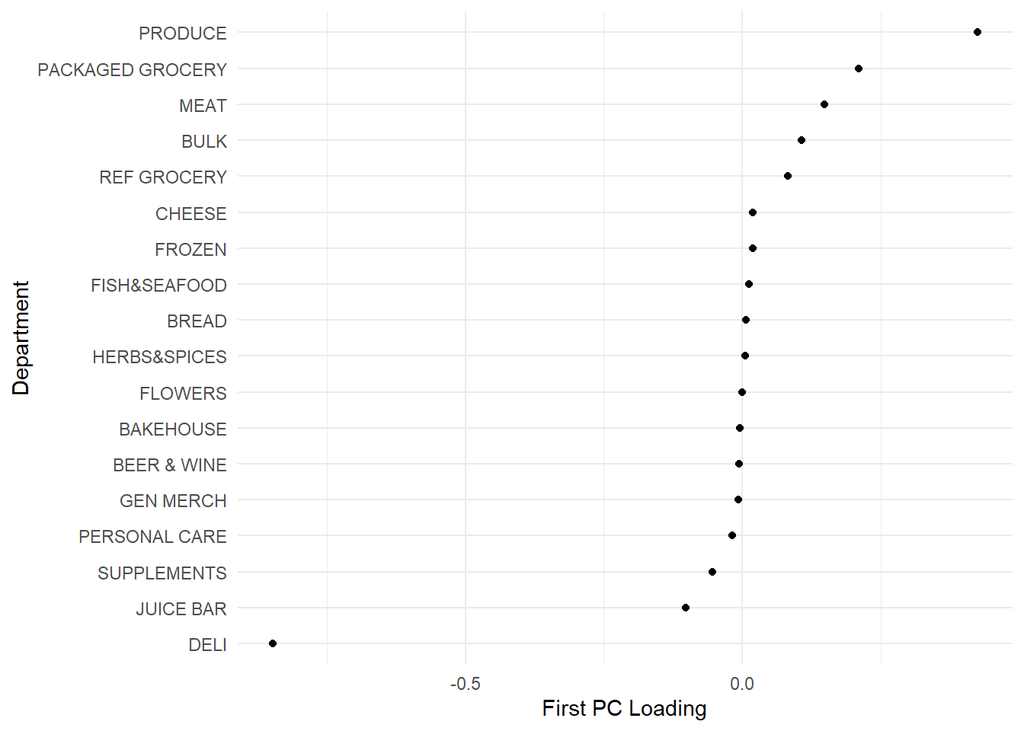

```r
for.plot <- tibble(loading = pca1$rotation[,1],
                   dept = names(pca1$rotation[,1]))

# put a sensible ordering on
for.plot <- for.plot %>%
  mutate(dept = forcats::fct_reorder(dept,loading))

ggplot(for.plot,
       aes(x=loading,y=dept)) +
  geom_point() +
  theme_minimal() +
  labs(x="First PC Loading",y="Department")
```

The first principal component is, essentially, deli shopping vs the more popular departments. Recall that we aren’t interested in loadings that close to zero and that the signs are arbitrary. At the bottom of the chart we have Deli, Juice Bar, and Suppplements. These are departments that have some very strong customers, but are less likely to be shopped on a regular basis. At the other end we have the “regular grocery” departments. A high score on PC1 would likely be a regular, full-grocery shopper, a low score would indicate someone who mostly used the Wedge for deli purchases.

Now, for you. Build a plot of the second principal component and interpret it here.

## Using PCA Output

The point of PCA is two-fold: to explore the structure of a data set and to reduce the dimensionality of the data. Let’s take a look at the latter in action.

Imagine we want to do a regression of total spend on the percentage of spend in each department. This regression has 18 explanatory variables and could have a pretty unwieldy output (particularly if there were hundreds of departments).

```r
pca.to.use <- 4

new.reg.dept <- dept %>% select(owner,total_spend) # a new data.frame for regression
new.names <- c("owner","total_spend")

for (i in 1:pca.to.use) {
  new.reg.dept <- cbind(new.reg.dept,
                        pca1$x[,i])

  new.names <- c(new.names,paste0("pca",i))
}

names(new.reg.dept) <- new.names
```

So we’ve built our new data set for regression. Let’s build our model.

```r
lm1 <- lm(total_spend ~ pca1 + pca2 + pca3 + pca4, # will use all the pca columns
          data = new.reg.dept,
          subset = total_spend < 20000) # get rid of very active owners

summary(lm1)
```

```
##
## Call:
## lm(formula = total_spend ~ pca1 + pca2 + pca3 + pca4, data = new.reg.dept,
##     subset = total_spend < 20000)
##
## Residuals:
##     Min      1Q  Median      3Q     Max
## -3164.7 -1138.5  -649.8   287.0 19666.9
##
## Coefficients:
##             Estimate Std. Error t value Pr(>|t|)
## (Intercept)  1413.94      16.17  87.464  < 2e-16 ***
## pca1         2196.81      93.97  23.378  < 2e-16 ***
## pca2          854.68     106.71   8.009 1.23e-15 ***
## pca3         -950.04     107.81  -8.812  < 2e-16 ***
## pca4          759.30     132.14   5.746 9.30e-09 ***
## ---
## Signif. codes:  0 '***' 0.001 '**' 0.01 '*' 0.05 '.' 0.1 ' ' 1
##
## Residual standard error: 2087 on 16662 degrees of freedom
## Multiple R-squared:  0.04142,    Adjusted R-squared:  0.04119
## F-statistic:   180 on 4 and 16662 DF,  p-value: < 2.2e-16
```

The residual standard error ($2,087) is not great and the $R^2$ is an abysmal 0.041. This is not a good model.

Question for you: Why might it make sense that the model doesn’t explain much of the variation in total spend?

Your answer:

All principal components are highly significant. Interpretation is tricky. We can say that an increase of 1 in PC1 leads to an additional spend of $2196 ($2008,$2384), but what does that *mean*? If you look at `new.reg.dept`, you’ll see that the first PC ranges from -0.89 to 0.38, so a change in 1 basically represents the full range of the data. So if someone goes from mostly shopping deli to mostly shopping the main part of the store, we’d expect, based on this not-very-good model, about $2200 more in total sales. As before, we can look at the vector of weights, called `rotation`s in R to get a sense of what that might mean.

From the chart above, we know this PC contrasts DELI and, to a lesser extent, JUICE BAR with PRODUCE, PACKAGED GROCERY, MEAT and BULK. Typically we focus on vars that have “large” loadings in absolute value. The signs is arbitrary; a result where we multiply **every** loading by -1 is exactly the same PCA. Here I chose 0.1 as my cutoff for “large”, but it’s a judgment call.

So, this first principal component is a measure of how much someone shops the “main” departments (produce, packaged grocery) versus how much they shop the “grab and go” departments. Even with the terrible $R^2$, we’re getting something useful here. If you shop the main departments you’re likely to spend more money in the store. Not rocket science, but a useful insight.

## Work For You

In addition to the questions above, I’d like you to perform a PCA on the owner-level sales for the top 1000 products. This data is stored in (pretty large) file `owner_level_top_prod_sales.txt`. The data is arranged so that each owner is on their own row. The first column is the owner number. The subsequent columns are the sales to that owner of the given product. Let’s read the data in and look at the distribution of sales across owners and across products.

```r
d2 <- read_tsv("owner_level_top_prod_sales.txt")
print(dim(d2)) # 2674 owners by 1000 products
```

```
## [1] 2674 1001
```

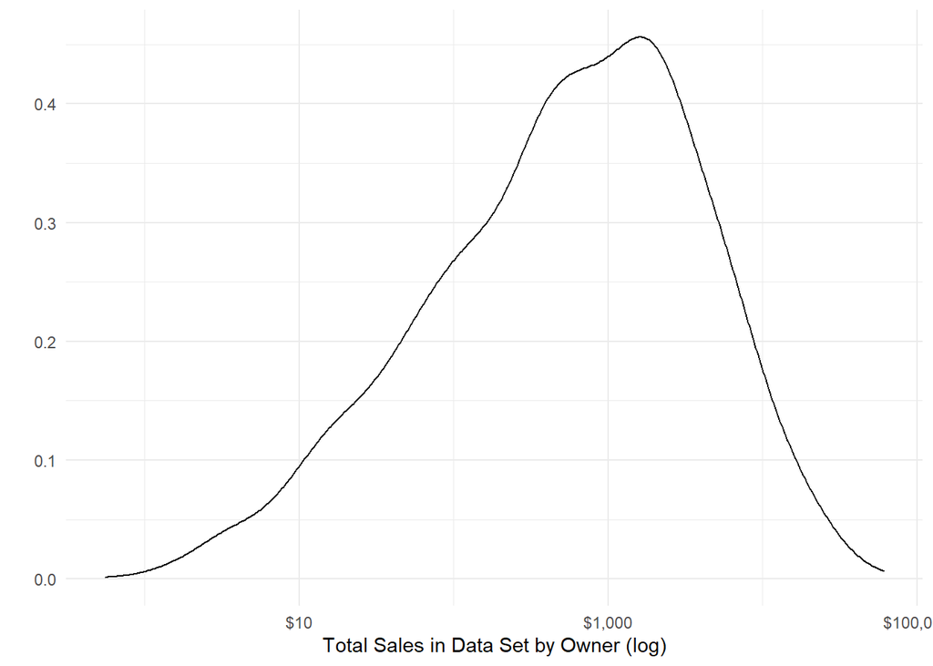

```r
for.plot <- data.frame(total_sales = rowSums(d2[,-1]))

ggplot(for.plot %>% filter(total_sales > 0),aes(x=total_sales)) +
  geom_density() +
  theme_minimal() +
  labs(y="",x="Total Sales in Data Set by Owner (log)") +
  scale_x_log10(label=dollar)
```

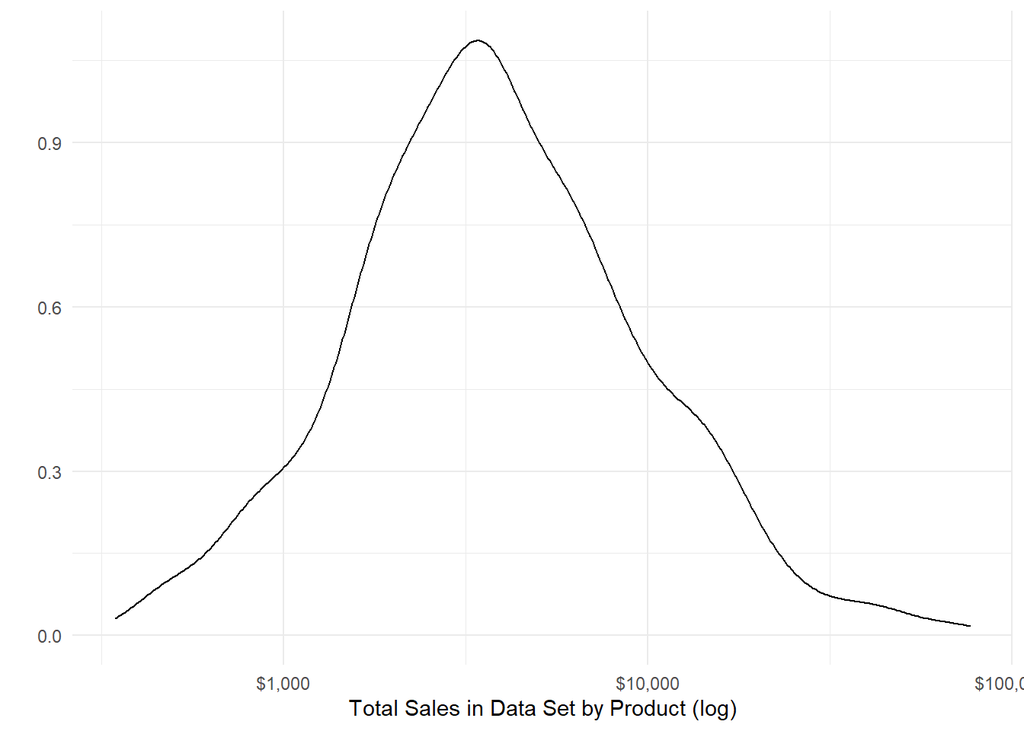

```r
for.plot <- data.frame(total_sales = colSums(d2[,-1]))

ggplot(for.plot %>% filter(total_sales > 0),aes(x=total_sales)) +
  geom_density() +
  theme_minimal() +
  labs(y="",x="Total Sales in Data Set by Product (log)") +
  scale_x_log10(label=dollar)
```

Briefly describe these distributions.

Now let’s do PCA on this data set (across products) and look at (and interpret) the first three principal components. Remember to remove the owner number from the PCA–we don’t want to try to explain variation in that. As we did before, plot the variance explained by components and the cumulative variance explained.

```r
# Build your pca
```

How many components do we need to get to 50% variation explained? What about 90%?

Now let’s look at and interpret the first three principal components. Since we have so many products, look at the distribution of the loadings and then choose a cutoff for each component. Your cutoff should allow you to visualize 20 to 30 products. Remember, we’re interested in loadings that are large in *absolute value*. Once you’ve selected which products to look at for each component, make a chart of the loadings by product and interpret the component.